# RPA_Clearance_Code_AM

**This code was used to import, process, and visualize kymographs, as well as compute the background-corrected photon count from a channel of interest and plot the photon count as a function of time graph, along with exporting the data as a .csv file**.

The required libraries were installed via Anaconda Prompt and called/imported here in the beginning.

```python
import lumicks.pylake as lk
import pandas as pd
import numpy as np
import matplotlib.pyplot as plt
```

Once inside the folder/working directory of interest which contains the .h5 kymograph files, we processed each file individually. Below, we have proceeded with one representative kymograph.

```python
file = lk.File("20241112-160656 Kymograph C2_DNA2_Kymo.h5")
print(file)
print(file.kymos)
```

[output not shown]

[output cut: 64 more lines]

[output not shown]

The following line of code is passed to define the kymograph file of interest that you want to employ for any subsequent code that you run. Ensure that if you import a new kymograph file after processing one, you must pass this line of code again to overwrite the previous working kymograph with the new one.

```python
for name, kymo in file.kymos.items():
    print(f"kymograph '{name}', starts at {kymo.start} ns")
```

```
kymograph 'C2_DNA2_Kymo', starts at 1731449216682301800 ns
```

```python
rgb = kymo.get_image("rgb")
```

First, we plot any short time window of the kymograph with all the colors on to get a sense of where the background region broadly lies.

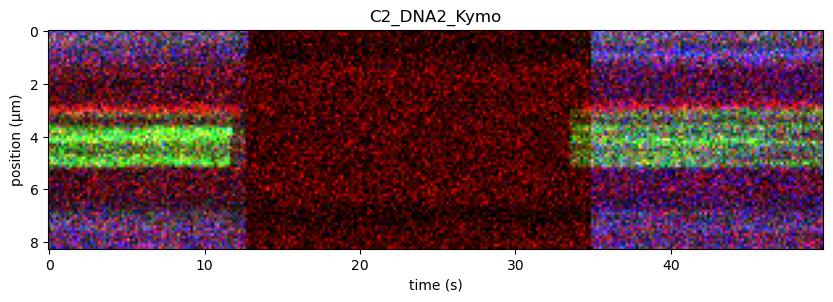

```python
f = plt.figure()
f.set_figwidth(10)
f.set_figheight(8)
kymo_new = kymo["0s":"50s"].plot("rgb", adjustment=lk.ColorAdjustment(0, 99, mode="percentile"))
plt.show()
```

We can also get a visual sense of how the signal of interest will change over time by plotting only one color.

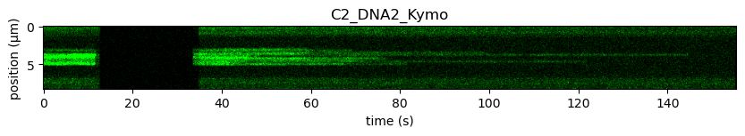

```python
f = plt.figure()
f.set_figwidth(10)
f.set_figheight(8)
kymo_new = kymo["0s":"160s"].plot("g", adjustment=lk.ColorAdjustment(0, 99, mode="percentile"))
plt.show()
```

Now, we pick a region outside out region of interest to define the background, and you can process the kymograph both, along the time and the distance axes to do so.

```python
background = kymo["40s":"60s"].crop_by_distance(5.4, 5.5)
green_background_per_pixel = np.sum(background.get_image("green"))
```

The last two lines of the code chunk can be used to save the data for photon counts as a .csv file and save the combined figure as a .png file.

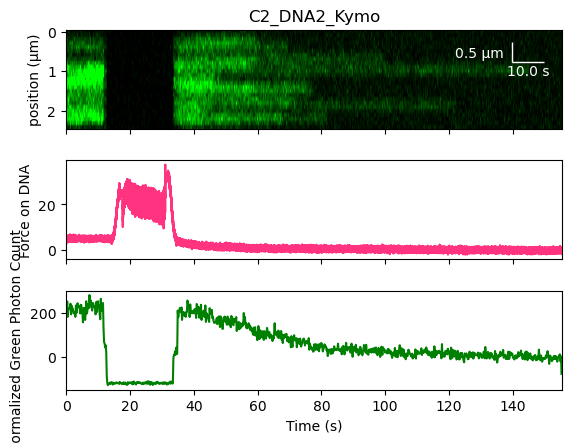

```python
# Calculate background-subtracted photon count
background_subtracted_photon_count = file["Photon count"]["Green"].downsampled_over(kymo.line_timestamp_ranges(), reduce=np.sum) - green_background_per_pixel

# Plot the background-subtracted photon count
kymo.crop_by_distance(2.9, 5.3).plot_with_channels(
    [
        file.force2x.downsampled_by(100),
        background_subtracted_photon_count,
    ],
    "g",
    adjustment=lk.ColorAdjustment(0, 98, "percentile"),
    aspect_ratio=0.2,
    title_vertical=True,
    scale_bar=lk.ScaleBar(10.0, 0.5),
    colors=[[1.0, 0.2, 0.5], "green"],
    labels=["Force on DNA", "Normalized Green Photon Count"],
)
time_counts =background_subtracted_photon_count.timestamps
time_counts = (time_counts - time_counts[0]) *1e-9
photon_counts=background_subtracted_photon_count.data
counts= np.vstack((time_counts,photon_counts)).T
#np.savetxt('C2_DNA2_Green_counts.csv',counts, delimiter=',', header='time counts')
#plt.savefig('DNA2_Condition2_GreenCount.png')
```